# MSBI 32000 Winter 2022 Semester

Framingham Heart Study Analysis

# Introdution

The Framingham Study is a “population-based, observational cohort study” started in 1948 by a federal public health agency. The goal has been to investigate cardiovascular disease. This data is a small subset of the larger study. The full data is complex and includes genetic and imaging results as well as the demographics and clinical data included in the subset. The full data has been instrumental in furthering understanding of cardiac conditions and outcomes.

Cardiac conditions are numerous and diverse. This data primary looks at a subset of cardiac conditions regarding coronary artery, coronary heart disease sequalae, and cerebral vascular disease. The coronary arteries are the arteries that supply the heart muscle with blood and oxygen to allow it to work to pump oxygenated blood throughout the body. There are many reasons for coronary vascular, including most prominently a build up of plaque. When blood flow is impeded in the artery, it causes ischemia (a lack of oxygen) which leads to angina (cardiac chest pain) and eventually a Myocardial Infarction (MI), a heart attack. Hypertension is a risk factor for coronary heart disease. Hypertension is elevate blood pressure. Many of the factors that cause affect the coronary arteries can also effect the cerebral arteries, arteries of the brain, and diseases of these can lead to strokes.

# Sources

- https://www.bmc.org/stroke-and-cerebrovascular-center/research/framingham-study

# Research Questions

Our first research question was to properly understand the data set. Our original dataframe had 11,627 records with 39 variables. First we wanted to understand what data was there, what data was missing, and what the distributions were. Therefore, we spent alot of time “cleaning” the data.

# Cleaning the Data

## Data Source and Description

First we had to set up the data in our R Studio. We downloaded the data from the dropbox site for the class and set it into a data frame.With this we loaded some libraries that would help us clean and evaluate the data.

```r
rm(list=ls())
library(plyr)
library(dplyr)
library(lubridate)
FRAMINGHAM.DL <- read.csv("https://www.dropbox.com/s/oxnn4uoj8lqujwm/frmgham2.csv?dl=1")
FRMGHAM.PT <- FRAMINGHAM.DL
```

## Data Exploration and Munging

Looking at the data initially, it appears that patients were followed for at least 3 periods, so many of the 11,000 + records were duplicated, and triplicated. Outcome data for each line was final outcome data and this was repeated for each period the patient was present so it was not unique for each visit. The prevalent disease columns however were unique for each visit.

```r
head(FRMGHAM.PT)
```

```
  RANDID SEX TOTCHOL AGE SYSBP DIABP CURSMOKE CIGPDAY   BMI DIABETES BPMEDS
1   2448   1     195  39   106    70        0       0 26.97        0      0
  HEARTRTE GLUCOSE educ PREVCHD PREVAP PREVMI PREVSTRK PREVHYP TIME PERIOD HDLC
1       80      77    4       0      0      0        0       0    0      1   NA
  LDLC DEATH ANGINA HOSPMI MI_FCHD ANYCHD STROKE CVD HYPERTEN TIMEAP TIMEMI
1   NA     0      0      1       1      1      0   1        0   8766   6438
  TIMEMIFC TIMECHD TIMESTRK TIMECVD TIMEDTH TIMEHYP
1     6438    6438     8766    6438    8766    8766
 [ reached 'max' / getOption("max.print") -- omitted 5 rows ]
```

Many of the data items were factor variables, so we converted those variables to factors. This included risk factors like sex, smoking history, education, prevalence of disease (diabetes, hypertension, CHD), use of medication, as well as outcome occurrences such as CHD events, strokes and death.

```r
#Setting Factor Variables
FRMGHAM.PT <- mutate(FRMGHAM.PT, educ= as.factor(educ),DIABETES=as.factor(DIABETES),
               SEX= as.factor(SEX), CURSMOKE=as.factor(CURSMOKE), BPMEDS=as.factor(BPMEDS),
               PREVCHD = as.factor(PREVCHD), PREVAP = as.factor(PREVAP),
               PREVMI = as.factor(PREVMI), PREVSTRK = as.factor(PREVSTRK),
               PREVHYP = as.factor(PREVHYP), PERIOD = as.factor(PERIOD),
               DEATH = as.factor(DEATH), ANGINA = as.factor(ANGINA),
               HOSPMI = as.factor(HOSPMI), MI_FCHD = as.factor(MI_FCHD),
               ANYCHD = as.factor(ANYCHD), STROKE = as.factor(STROKE),
               CVD = as.factor(CVD), HYPERTEN = as.factor(HYPERTEN))
```

The last few column were the dates when a certain event happened (like heart attack or chest pain) but also included was the last date the patient had contact with the study. Given we had a factor variable if the event occurred or not, we created new columns that held the time the event occurred only if the event occurred. We then deleted the original time columns.

```r
FRMGHAM.PT$TIMEMIFC_OCCURRED <- ifelse(FRMGHAM.PT$MI_FCHD == 1, FRMGHAM.PT$TIMEMIFC, NA)
FRMGHAM.PT$TIMEMI_OCCURRED <- ifelse(FRMGHAM.PT$HOSPMI == 1, FRMGHAM.PT$TIMEMI, NA)
FRMGHAM.PT$TIMECHD_OCCURRED <- ifelse(FRMGHAM.PT$ANYCHD == 1, FRMGHAM.PT$TIMECHD, NA)
FRMGHAM.PT$TIMESTRK_OCCURRED <- ifelse(FRMGHAM.PT$STROKE == 1, FRMGHAM.PT$TIMESTRK, NA)
FRMGHAM.PT$TIMECVD_OCCURRED <- ifelse(FRMGHAM.PT$CVD == 1, FRMGHAM.PT$TIMECVD, NA)
FRMGHAM.PT$TIMEDEATH_OCCURRED <- ifelse(FRMGHAM.PT$DEATH == 1, FRMGHAM.PT$TIMEDTH, NA)
FRMGHAM.PT$TIMEHYP_OCCURRED <- ifelse(FRMGHAM.PT$HYPERTEN == 1, FRMGHAM.PT$TIMEHYP, NA)
FRMGHAM.PT$TIMEAP_OCCURRED <- ifelse(FRMGHAM.PT$ANGINA == 1, FRMGHAM.PT$TIMEAP,NA)

#Removing the original columns that had last seen dates
FRMGHAM.PT <- FRMGHAM.PT[-c(32:39)]

#Creating a data frame with just numerically coded data.
FRMGHAM.PT.CODED <- FRMGHAM.PT
```

For the numerically coded values, we wanted to be able to interpret them with English text not using a key, so we created labels for all the factor data

```r
#Setting Factor Level Names
levels(FRMGHAM.PT$SEX) <- c('Men', 'Women')
levels(FRMGHAM.PT$PERIOD) <- c('Period 1', 'Period 2','Period 3')
levels(FRMGHAM.PT$BPMEDS) <- c('No BP Meds', 'Currently Using BP Meds')
levels(FRMGHAM.PT$CURSMOKE) <- c('NonSmoker', 'Currently Smoker')
levels(FRMGHAM.PT$educ) <- c('0-11 years', 'High School Diploma, GED','Some College, Vocational School', 'College (BS, BA) degree or more')
levels(FRMGHAM.PT$DIABETES) <- c('None', 'Diabetes History')
levels(FRMGHAM.PT$PREVHYP) <- c('None', 'HTN History')
levels(FRMGHAM.PT$PREVAP) <- c('None', 'Angina History')
levels(FRMGHAM.PT$PREVCHD) <- c('None', 'Coronary HD History')
levels(FRMGHAM.PT$PREVMI) <- c('None', 'MI History')
levels(FRMGHAM.PT$PREVSTRK) <- c('None', 'Stroke History')
levels(FRMGHAM.PT$DEATH) <- c('None', 'DEATH OCCURRED')
levels(FRMGHAM.PT$ANGINA) <- c('None', 'ANGINA OCCURRED')
levels(FRMGHAM.PT$HOSPMI) <- c('None', 'MI OCCURRED')
levels(FRMGHAM.PT$MI_FCHD) <- c('None', 'MI OR FATAL CHD OCCURED')
levels(FRMGHAM.PT$ANYCHD) <- c('None', 'CHD OCCURRED')
levels(FRMGHAM.PT$STROKE) <- c('None', 'STROKE OCCURRED')
levels(FRMGHAM.PT$CVD) <- c('None', 'CVD OCCURRED')
levels(FRMGHAM.PT$HYPERTEN) <- c('None', 'HTN OCCURRED')
```

Now that we had a data frame with data we could read, we wanted to understand the outcomes better. We knew that many of the records were repeat patients so we had to split them up into different periods. We separated the data frame into 3 different data frames by the period. We then dropped repeated columns that didn’t change over the evaluation period or weren’t measured in that period. The columns we dropped were:

- sex (from data frames 2 and 3)
- education (from data frames 2 and 3)
- period labels (from all data frames)
- time (from data from 1 as it was always 0)
- HDL and LDL (from data frames 1 and 2) as these were only measured at the 3rd period
- outcome data (from data frames 2 and 3) as these were the same for all 3 periods

We then relabeled the columns except for RANDID (patient identifier in order to eventually join) with the period the new data came from.

```r
#splitting the data into dataframes and removing the uncessary columns.
FRMGHAM.PT_P.1 <- FRMGHAM.PT[FRMGHAM.PT$PERIOD =="Period 1",] %>% .[-c(20:23)]
FRMGHAM.PT_P.2 <- FRMGHAM.PT[FRMGHAM.PT$PERIOD =="Period 2",] %>% .[-c(2,14,21:47)]
FRMGHAM.PT_P.3 <- FRMGHAM.PT[FRMGHAM.PT$PERIOD =="Period 3",] %>% .[-c(2,14,21,24:47)]

#renaming the columns
colnames(FRMGHAM.PT_P.2) <- paste("P2", colnames(FRMGHAM.PT_P.2), sep = "_")
names(FRMGHAM.PT_P.2)[1] <- 'RANDID'
colnames(FRMGHAM.PT_P.3) <- paste("P3", colnames(FRMGHAM.PT_P.3), sep = "_")
names(FRMGHAM.PT_P.3)[1] <- 'RANDID'
```

Finally we joined the data to create 2 finalized and completed data frames. The first data frame was created by outer joining the first period to the second period and then again outer joining that to the third period to create a dataframe with all possible patients.

```r
#outerjoins
FRAMINGHAM.CLEAN <- merge(FRMGHAM.PT_P.1, FRMGHAM.PT_P.2, by = "RANDID", all = TRUE) %>% merge(., FRMGHAM.PT_P.3, by = "RANDID", all = TRUE)
```

The second option was created by using inner joins so it is just all the patients that presented for all 3 periods.

```r
#inner joins
FRAMINGHAM.CLEAN.ALL3 <- merge(FRMGHAM.PT_P.1, FRMGHAM.PT_P.2, by = "RANDID") %>% merge(., FRMGHAM.PT_P.3, by = "RANDID")
```

## Variable List

```r
str(FRAMINGHAM.CLEAN)
```

```
'data.frame':   4434 obs. of  71 variables:
 $ RANDID            : int  2448 6238 9428 10552 11252 11263 12629 12806 14367 16365 ...
 $ SEX               : Factor w/ 2 levels "Men","Women": 1 2 1 2 2 2 2 2 1 1 ...
 $ TOTCHOL           : int  195 250 245 225 285 228 205 313 260 225 ...
 $ AGE               : int  39 46 48 61 46 43 63 45 52 43 ...
 $ SYSBP             : num  106 121 128 150 130 ...
 $ DIABP             : num  70 81 80 95 84 110 71 71 89 107 ...
 $ CURSMOKE          : Factor w/ 2 levels "NonSmoker","Currently Smoker": 1 1 2 2 2 1 1 2 1 2 ...
 $ CIGPDAY           : int  0 0 20 30 23 0 0 20 0 30 ...
 $ BMI               : num  27 28.7 25.3 28.6 23.1 ...
 $ DIABETES          : Factor w/ 2 levels "None","Diabetes History": 1 1 1 1 1 1 1 1 1 1 ...
 $ BPMEDS            : Factor w/ 2 levels "No BP Meds","Currently Using BP Meds": 1 1 1 1 1 1 1 1 1 1 ...
 $ HEARTRTE          : int  80 95 75 65 85 77 60 79 76 93 ...
 $ GLUCOSE           : int  77 76 70 103 85 99 85 78 79 88 ...
 $ educ              : Factor w/ 4 levels "0-11 years","High School Diploma, GED",..: 4 2 1 3 3 2 1 2 1 1 ...
```

[output cut: 57 more lines]

### Period 1 Visit

- RANDID : Unique Identifier
- SEX : Sex
- TOTCHOL : Serum Total Cholesterol (mg/dl)
- AGE : Age (years)
- SYSBP : Mean Systolic of Last 2 Measurements (mmHg)
- DIABP : Mean Diastolic of Last 2 Measurements (mmHg)
- CURSMOKE : Current Cigarette Smoker
- CIGPDAY : # of Cigarettes per Day
- BMI : BMI (kg/m2)
- DIABETES : Diabetic
- BPMEDS : On Blood Pressure Medications at Exam
- HEARTRTE : Heart Rate (beats/min)
- GLUCOSE : Random serum glucose (mg/dl)
- educ : Max. Attained Education
- PREVCHD : Coronary Heart Disease Present / Not Present
- PREVAP : Angina Present / Not Present
- PREVMI : Myocardial Infarction Hx Present / Not Present
- PREVSTRK : Stroke Hx Present / Not Present
- PREVHYP : Hypertension Present / Not Present
- DEATH : Death Occurred / Did Not Occurr
- ANGINA : Angina Pectoris Occurred / Did Not Occur
- HOSPMI : Hospitalized with MI Occurred / Did Not Occur
- MI_FCHD : Hospitalized with MI or Fatal CHD Occurred / Did Not Occur
- ANYCHD : Coronary Heart Disease (CHD) Occurred / Did Not Occur (CHD = Angina Pectoris, MI, Coronary Insufficiency or Fatal CHD)
- STROKE : Stroke Occurred / Did Not Occur (Stroke = Atherothrombotic Infarct, Cerebral Embolism, Intercerebral Hemorrhage, Subarachnoid Hemorrhage or Fatal Cerebrovascular Dx)
- CVD : CVD Occurred / Did Not Occur (CVD = MI, Fatal CHD, or Stroke)
- HYPERTEN : Hypertension Occurred / Did Not Occurr
- TIMEMIFC_OCCURRED : Time First Episode of MI_CHD (days from Period 1 Visit)
- TIMEMI_OCCURRED : Time First Episode of MI (days from Period 1 Visit)
- TIMECHD_OCCURRED : Time First Episode of CHD (days from Period 1 Visit)
- TIMESTRK_OCCURRED : Time First Episode of STROKE (days from Period 1 Visit)
- TIMECVD_OCCURRED : Time First Episode of CVD (days from Period 1 Visit)
- TIMEDEATH_OCCURRED: Time Episode of Death (days from Period 1 Visit) of any cause
- TIMEHYP_OCCURRED : Time First Episode of HYPERTEN (days from Period 1 Visit)
- TIMEAP_OCCURRED : Time First Episode of ANGINA (days from Period 1 Visit)

### Period 2 Visit

- P2_TOTCHOL : Serum Total Cholesterol (mg/dl)
- P2_AGE : Age (years)
- P2_SYSBP : Mean Systolic of Last 2 Measurements (mmHg)
- P2_DIABP : Mean Diastolic of Last 2 Measurements (mmHg)
- P2_CURSMOKE : Current Cigarette Smoker
- P2_CIGPDAY : # of Cigarettes per Day
- P2_BMI : BMI (kg/m2)
- P2_DIABETES : Diabetic
- P2_BPMEDS : On Blood Pressure Meds
- P2_HEARTRTE : Heart Rate (beats/min)
- P2_GLUCOSE : Random serum glucose (mg/dl)
- P2_PREVCHD : Coronary Heart Disease Present / Not Present
- P2_PREVAP : Angina Present / Not Present
- P2_PREVMI : Myocardial Infarction Hx Present / Not Present
- P2_PREVSTRK : Stroke Hx Present / Not Present
- P2_PREVHYP : Hypertension Present / Not Present
- P2_TIME : Days since Period 1 Visit

### Period 3 Visit

- P3_TOTCHOL : Serum Total Cholesterol (mg/dl)
- P3_AGE : Age (years)
- P3_SYSBP : Mean Systolic of Last 2 Measurements (mmHg)
- P3_DIABP : Mean Diastolic of Last 2 Measurements (mmHg)
- P3_CURSMOKE : Current Smoker
- P3_CIGPDAY : # of Cigarettes per Day
- P3_BMI : BMI (kg/m2)
- P3_DIABETES : Diabetic
- P3_BPMEDS : On Blood Pressure Meds
- P3_HEARTRTE : Heart Rate (beats/min)
- P3_GLUCOSE : Random serum glucose (mg/dl)
- P3_PREVCHD : Coronary Heart Disease Present / Not Present
- P3_PREVAP : Angina Present / Not Present
- P3_PREVMI : Myocardial Infarction Hx Present / Not Present
- P3_PREVSTRK : Stroke Hx Present / Not Present
- P3_PREVHYP : Hypertension Present / Not Present
- P3_TIME : Days since Period 1 Visit
- P3_HDLC : High Density Lipoprotein Cholesterol (mg/dl)
- P3_LDLC : Low Density Lipoprotein Cholesterol (mg/dl)

# Variable NA

## NA Values in Columns

From the innner join data frame, we temporarilty removed columns where we created NAs (data columns of events when the event did not exist) and counted the missing values.

The most common missing value was glucose followed by if the patient was on BP Meds

```r
FRAMINGHAM.MISSING <- sapply(FRAMINGHAM.CLEAN.ALL3[-c(28:35)], function(x) sum(is.na(x)))

print(FRAMINGHAM.MISSING)
```

```
     RANDID         SEX     TOTCHOL         AGE       SYSBP       DIABP
          0           0          32           0           0           0
   CURSMOKE     CIGPDAY         BMI    DIABETES      BPMEDS    HEARTRTE
          0          26           7           0          40           0
    GLUCOSE        educ     PREVCHD      PREVAP      PREVMI    PREVSTRK
        299          82           0           0           0           0
    PREVHYP       DEATH      ANGINA      HOSPMI     MI_FCHD      ANYCHD
          0           0           0           0           0           0
     STROKE         CVD    HYPERTEN  P2_TOTCHOL      P2_AGE    P2_SYSBP
          0           0           0         110           0           0
   P2_DIABP P2_CURSMOKE  P2_CIGPDAY      P2_BMI P2_DIABETES   P2_BPMEDS
          0           0          22           9           0          76
P2_HEARTRTE  P2_GLUCOSE  P2_PREVCHD   P2_PREVAP   P2_PREVMI P2_PREVSTRK
          0         383           0           0           0           0
 P2_PREVHYP     P2_TIME  P3_TOTCHOL      P3_AGE    P3_SYSBP    P3_DIABP
          0           0         210           0           0           0
P3_CURSMOKE  P3_CIGPDAY      P3_BMI P3_DIABETES   P3_BPMEDS P3_HEARTRTE
          0          11          14           0         440           2
 P3_GLUCOSE  P3_PREVCHD   P3_PREVAP   P3_PREVMI P3_PREVSTRK  P3_PREVHYP
        555           0           0           0           0           0
    P3_TIME     P3_HDLC     P3_LDLC
          0         231         232
```

A quick graph to see the frequency of missing values.

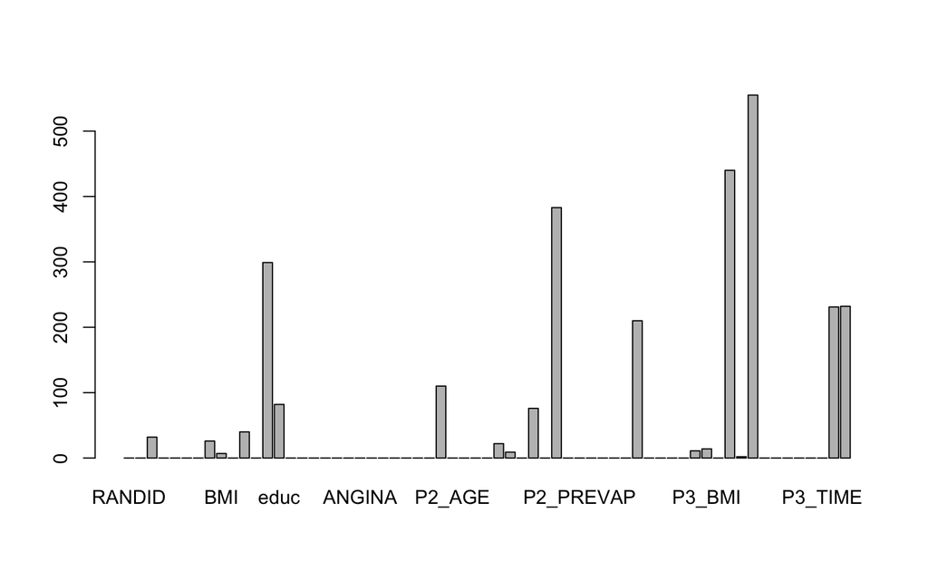

```r
barplot(FRAMINGHAM.MISSING)
```

# Modeling

World Health Organization has estimated 12 million deaths occur worldwide, every year due to Heart diseases. The early prognosis of cardiovascular diseases can aid in making decisions on lifestyle changes in high risk patients and in turn reduce the complications. With the numerous variables in the Framingham dataset, we would like to identify the most relevant/risk factors of heart disease as well as predict the overall risk using logistic regression.

Logistic regression is a type of regression analysis in statistics used for prediction of outcome of a binary categorical dependent variable from a set of predictor.

## Lasso

### Creating a Dataframe for Lasso

```r
LassoData <- FRAMINGHAM.CLEAN.ALL3[, c("educ", "DIABETES", "SEX", "CURSMOKE", "BPMEDS", "PREVCHD", "PREVAP", "PREVMI", "PREVSTRK", "PREVHYP", "TOTCHOL", "AGE", "SYSBP", "DIABP", "CIGPDAY", "BMI", "HEARTRTE", "GLUCOSE", "ANYCHD")]
lassoData <- na.omit(LassoData)
```

### Exploring Variables for the Lasso Model

#### Bar Plots for Factor Variables Looking Based on ANYCHD Occuring

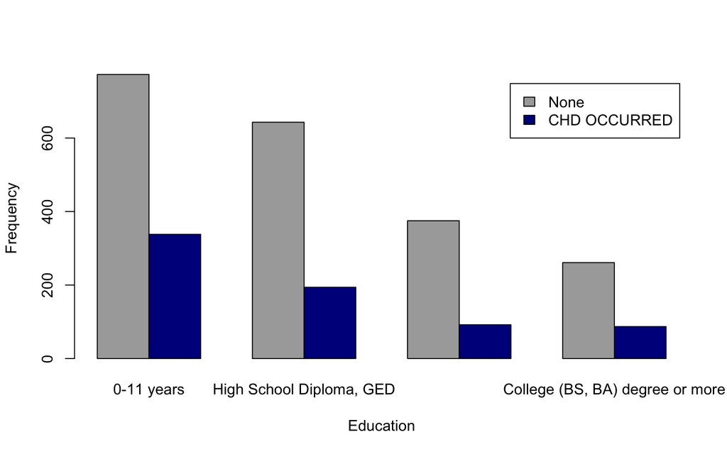

```r
#EDU
Educ_table <-table(lassoData$ANYCHD,lassoData$educ)

educ_bar <- barplot(Educ_table,
        xlab = "Education", ylab = "Frequency",
        col = c("darkgrey", "darkblue"),
        legend.text = rownames(Educ_table),
        beside = TRUE)
```

```r
print(educ_bar)
```

```
     [,1] [,2] [,3] [,4]
[1,]  1.5  4.5  7.5 10.5
[2,]  2.5  5.5  8.5 11.5
```

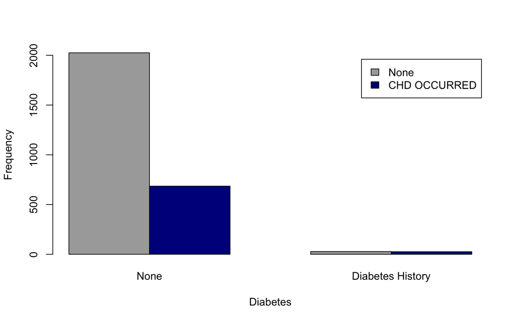

```r
#Diabetes
Diab_table <-table(lassoData$ANYCHD,lassoData$DIABETES)

DIAB_bar <- barplot(Diab_table,
        xlab = "Diabetes", ylab = "Frequency",
        col = c("darkgrey", "darkblue"),
        legend.text = rownames(Diab_table),
        beside = TRUE)
```

```r
print(DIAB_bar)
```

```
     [,1] [,2]
[1,]  1.5  4.5
[2,]  2.5  5.5
```

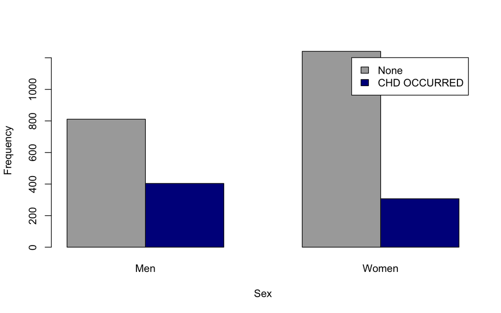

```r
#Sex
SEX_table <-table(lassoData$ANYCHD,lassoData$SEX)

sex_bar <- barplot(SEX_table,
        xlab = "Sex", ylab = "Frequency",
        col = c("darkgrey", "darkblue"),
        legend.text = rownames(SEX_table),
        beside = TRUE)
```

```r
print(sex_bar)
```

```
     [,1] [,2]
[1,]  1.5  4.5
[2,]  2.5  5.5
```

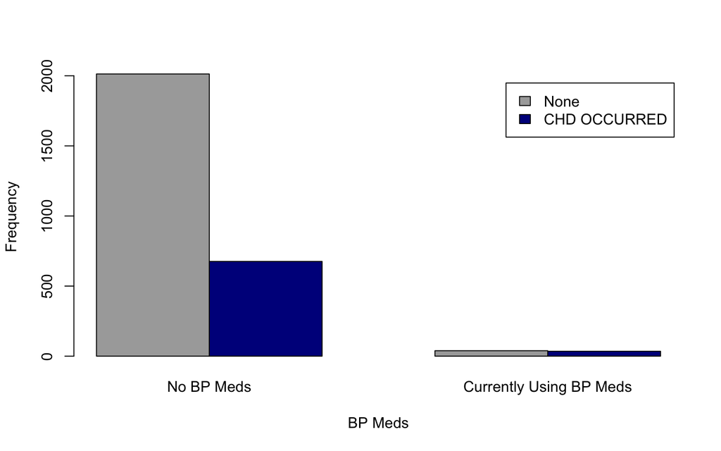

```r
#BPMEDS
BPMEDS_table <-table(lassoData$ANYCHD,lassoData$BPMEDS)

BPMEDS_bar <- barplot(BPMEDS_table,
        xlab = "BP Meds", ylab = "Frequency",
        col = c("darkgrey", "darkblue"),
        legend.text = rownames(BPMEDS_table),
        beside = TRUE)
```

```r
print(BPMEDS_bar)
```

```
     [,1] [,2]
[1,]  1.5  4.5
[2,]  2.5  5.5
```

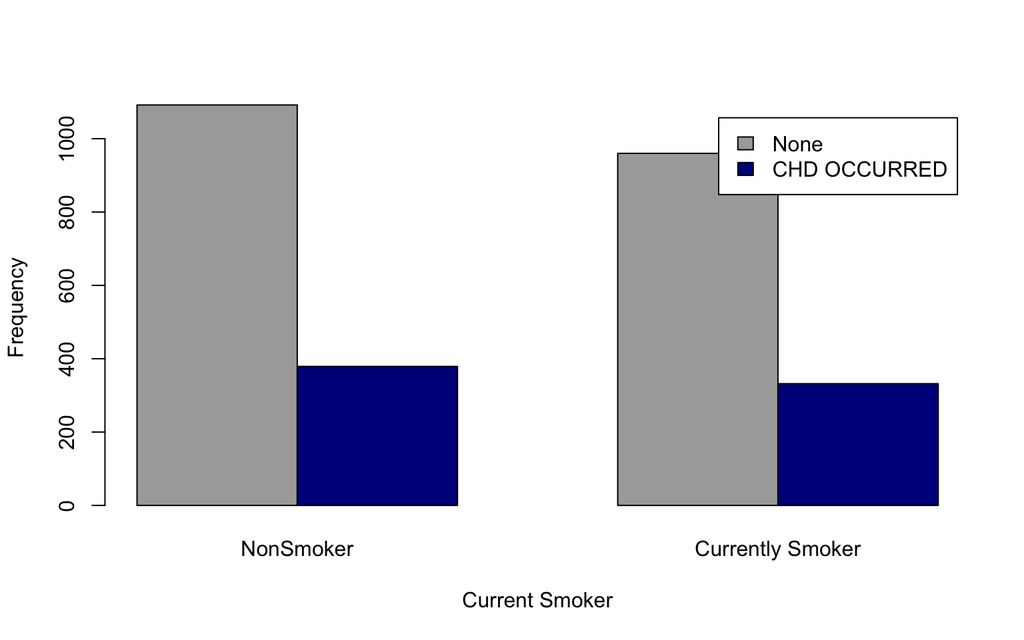

```r
#CURSMOKE
SMOKE_table <-table(lassoData$ANYCHD,lassoData$CURSMOKE)

smoke_bar <- barplot(SMOKE_table,
        xlab = "Current Smoker", ylab = "Frequency",
        col = c("darkgrey", "darkblue"),
        legend.text = rownames(SMOKE_table),
        beside = TRUE)
```

```r
print(smoke_bar)
```

```
     [,1] [,2]
[1,]  1.5  4.5
[2,]  2.5  5.5
```

#### Box Plots Numeric Variables Looking Based on ANYCHD Occuring

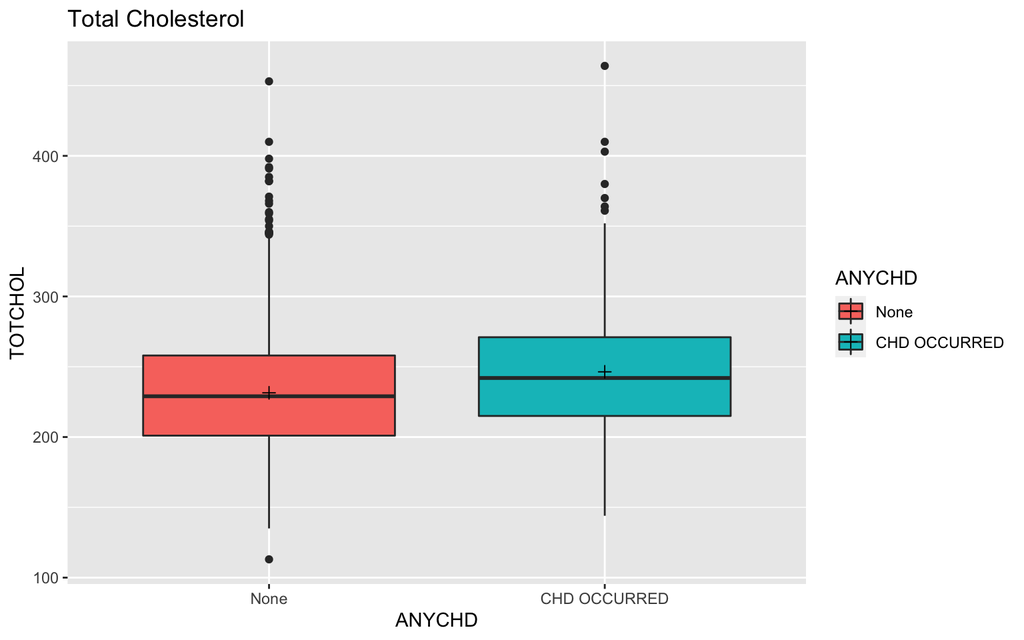

```r
library(ggplot2)

#Looking at period 1 variables

#tot chol
chol_chart <- ggplot(lassoData, aes(x = ANYCHD , y = TOTCHOL, fill=ANYCHD))
chol_chart <- chol_chart  + geom_boxplot()
# add a "+" at the mean
chol_chart  <- chol_chart  + stat_summary(fun.y = mean, geom = "point", shape = 3, size = 2)

chol_chart  <- chol_chart + labs(title = "Total Cholesterol")
print(chol_chart)
```

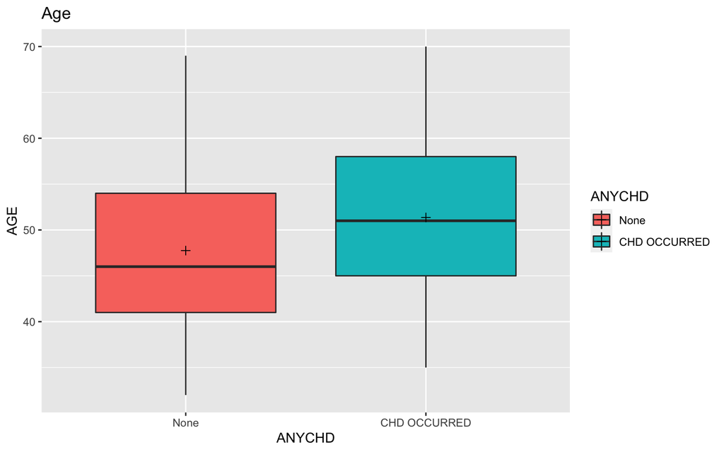

```r
#Age
age_chart <- ggplot(lassoData, aes(x = ANYCHD , y = AGE, fill=ANYCHD))
age_chart <- age_chart  + geom_boxplot()
# add a "+" at the mean
age_chart  <- age_chart  + stat_summary(fun.y = mean, geom = "point", shape = 3, size = 2)

age_chart  <- age_chart + labs(title = "Age")
print(age_chart)
```

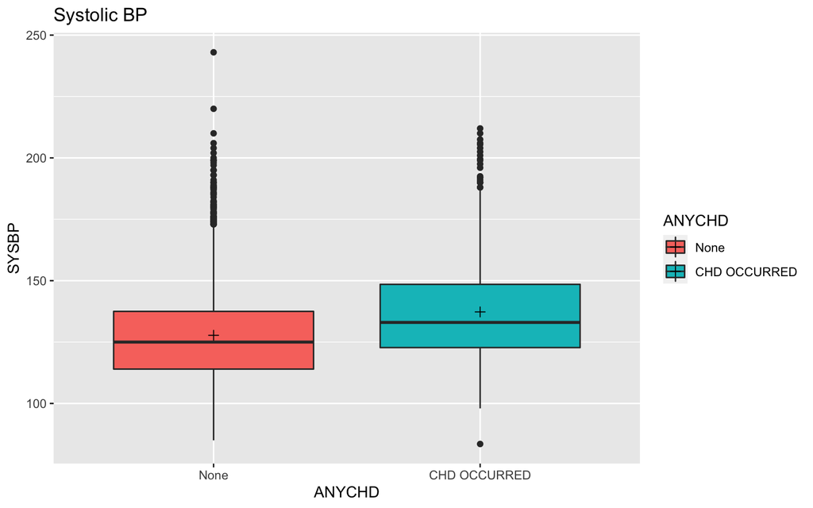

```r
#SysBP
sysbp_chart <- ggplot(lassoData, aes(x = ANYCHD , y = SYSBP, fill=ANYCHD))
sysbp_chart <- sysbp_chart  + geom_boxplot()
# add a "+" at the mean
sysbp_chart  <- sysbp_chart  + stat_summary(fun.y = mean, geom = "point", shape = 3, size = 2)

sysbp_chart  <- sysbp_chart + labs(title = "Systolic BP")
print(sysbp_chart)
```

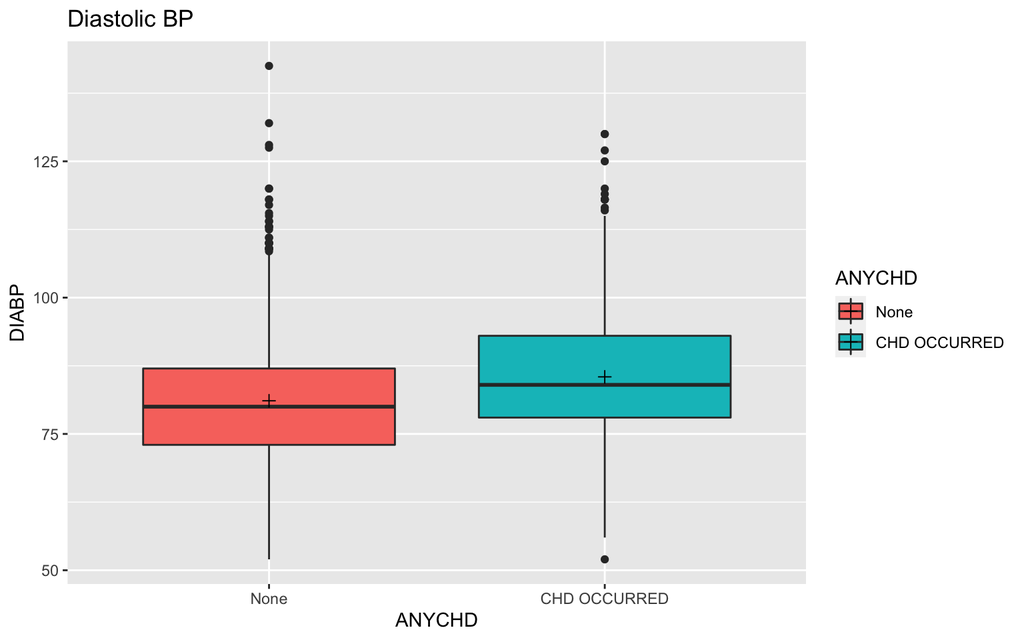

```r
#DiaBP
diabp_chart <- ggplot(lassoData, aes(x = ANYCHD , y = DIABP, fill=ANYCHD))
diabp_chart <- diabp_chart  + geom_boxplot()
# add a "+" at the mean
diabp_chart  <- diabp_chart  + stat_summary(fun.y = mean, geom = "point", shape = 3, size = 2)

diabp_chart  <- diabp_chart + labs(title = "Diastolic BP")
print(diabp_chart)
```

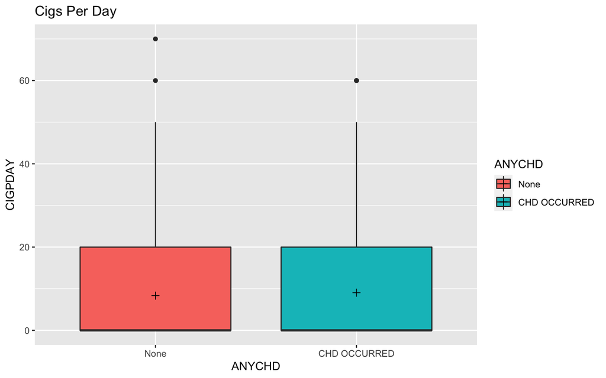

```r
#CIGPDAY
cig_chart <- ggplot(lassoData, aes(x = ANYCHD , y = CIGPDAY, fill=ANYCHD))
cig_chart <- cig_chart  + geom_boxplot()
# add a "+" at the mean
cig_chart  <- cig_chart  + stat_summary(fun.y = mean, geom = "point", shape = 3, size = 2)

cig_chart  <- cig_chart + labs(title = "Cigs Per Day")
print(cig_chart)
```

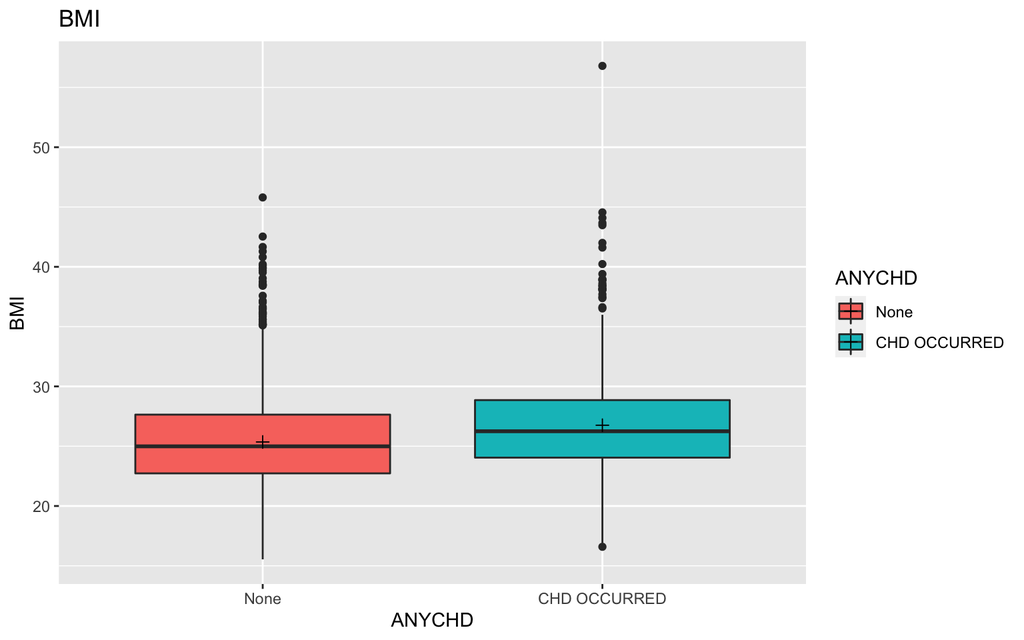

```r
#BMI
bmi_chart <- ggplot(lassoData, aes(x = ANYCHD , y = BMI, fill=ANYCHD))
bmi_chart <- bmi_chart  + geom_boxplot()
# add a "+" at the mean
bmi_chart  <- bmi_chart  + stat_summary(fun.y = mean, geom = "point", shape = 3, size = 2)

bmi_chart  <- bmi_chart + labs(title = "BMI")
print(bmi_chart)
```

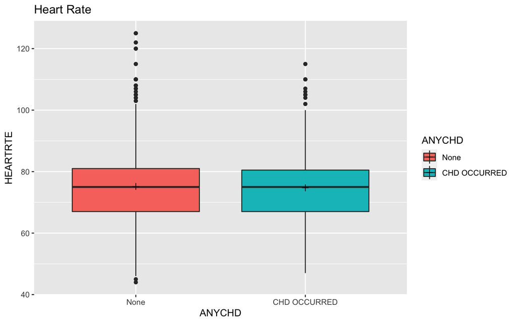

```r
#HEARTRTE
HR_chart <- ggplot(lassoData, aes(x = ANYCHD , y = HEARTRTE, fill=ANYCHD))
HR_chart <- HR_chart  + geom_boxplot()
# add a "+" at the mean
HR_chart  <- HR_chart  + stat_summary(fun.y = mean, geom = "point", shape = 3, size = 2)

HR_chart  <- HR_chart + labs(title = "Heart Rate")
print(HR_chart)
```

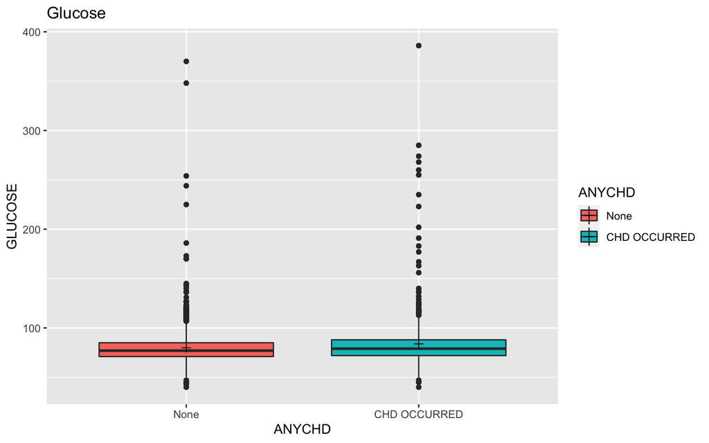

```r
#Glucose
glc_chart <- ggplot(lassoData, aes(x = ANYCHD , y = GLUCOSE, fill=ANYCHD))
glc_chart <- glc_chart  + geom_boxplot()
# add a "+" at the mean
glc_chart  <- glc_chart  + stat_summary(fun.y = mean, geom = "point", shape = 3, size = 2)

glc_chart  <- glc_chart + labs(title = "Glucose")
print(glc_chart)
```

```r
education <- ggplot(lassoData, aes(educ,counts))
```

### The Model

Running a regression model with many variables including irrelevant ones will lead to a needlessly complex model. Forward, backward and Stepwise regression are methods of selecting important variables fo fitting regression models with the choice of predictive variables, carried out by an automatic procedure.

```r
#fullmodel
full.model <- glm(ANYCHD ~ educ + DIABETES + SEX + CURSMOKE + BPMEDS + PREVAP + PREVMI + PREVSTRK + PREVHYP + TOTCHOL + AGE + SYSBP + DIABP + CIGPDAY + BMI + HEARTRTE + GLUCOSE,family="binomial", data=lassoData)
options(max.print=1000000)
summary(full.model)
```

```
Call:
glm(formula = ANYCHD ~ educ + DIABETES + SEX + CURSMOKE + BPMEDS +
    PREVAP + PREVMI + PREVSTRK + PREVHYP + TOTCHOL + AGE + SYSBP +
    DIABP + CIGPDAY + BMI + HEARTRTE + GLUCOSE, family = "binomial",
    data = lassoData)

Deviance Residuals:
     Min        1Q    Median        3Q       Max
-1.74307  -0.76560  -0.55188   0.00032   2.57097

Coefficients:
                                      Estimate Std. Error z value Pr(>|z|)
(Intercept)                         -6.461e+00  7.030e-01  -9.191  < 2e-16 ***
educHigh School Diploma, GED        -9.067e-02  1.170e-01  -0.775 0.438402
educSome College, Vocational School -3.381e-01  1.480e-01  -2.285 0.022304 *
educCollege (BS, BA) degree or more -1.891e-01  1.564e-01  -1.210 0.226455
DIABETESDiabetes History             4.438e-01  3.611e-01   1.229 0.219068
SEXWomen                            -8.105e-01  1.056e-01  -7.676 1.64e-14 ***
CURSMOKECurrently Smoker             1.787e-01  1.579e-01   1.131 0.257930
BPMEDSCurrently Using BP Meds        2.537e-01  2.803e-01   0.905 0.365318
PREVAPAngina History                 1.688e+01  3.028e+02   0.056 0.955558
PREVMIMI History                     1.661e+01  3.593e+02   0.046 0.963130
PREVSTRKStroke History              -2.807e-01  8.672e-01  -0.324 0.746183
PREVHYPHTN History                  -3.806e-02  1.410e-01  -0.270 0.787167
TOTCHOL                              6.258e-03  1.151e-03   5.437 5.43e-08 ***
AGE                                  2.788e-02  6.569e-03   4.244 2.20e-05 ***
SYSBP                                1.601e-02  4.302e-03   3.721 0.000199 ***
DIABP                               -3.635e-05  7.148e-03  -0.005 0.995943
CIGPDAY                              3.711e-04  6.625e-03   0.056 0.955333
BMI                                  3.752e-02  1.306e-02   2.873 0.004062 **
HEARTRTE                            -7.987e-03  4.289e-03  -1.862 0.062578 .
GLUCOSE                              4.517e-03  2.650e-03   1.705 0.088261 .
---
Signif. codes:  0 '***' 0.001 '**' 0.01 '*' 0.05 '.' 0.1 ' ' 1

(Dispersion parameter for binomial family taken to be 1)

    Null deviance: 3151.2  on 2762  degrees of freedom
Residual deviance: 2708.4  on 2743  degrees of freedom
AIC: 2748.4

Number of Fisher Scoring iterations: 15
```

```r
#Nothing Model
nothing.model <- glm(ANYCHD ~ 1, data=lassoData, family=binomial)
summary(nothing.model)
```

```
Call:
glm(formula = ANYCHD ~ 1, family = binomial, data = lassoData)

Deviance Residuals:
    Min       1Q   Median       3Q      Max
-0.7714  -0.7714  -0.7714   1.6477   1.6477

Coefficients:
            Estimate Std. Error z value Pr(>|z|)
(Intercept) -1.05990    0.04352  -24.36   <2e-16 ***
---
Signif. codes:  0 '***' 0.001 '**' 0.01 '*' 0.05 '.' 0.1 ' ' 1

(Dispersion parameter for binomial family taken to be 1)

    Null deviance: 3151.2  on 2762  degrees of freedom
Residual deviance: 3151.2  on 2762  degrees of freedom
AIC: 3153.2

Number of Fisher Scoring iterations: 4
```

```r
#backward regression
library(leaps)
backward.model <- step(full.model, direction = "backward", trace=0)
library(jtools)
summ(backward.model)
```

| Observations | 2763 |
| --- | --- |
| Dependent variable | ANYCHD |
| Type | Generalized linear model |
| Family | binomial |
| Link | logit |

| 𝛘²(10) | 434.53 |
| --- | --- |
| Pseudo-R² (Cragg-Uhler) | 0.21 |
| Pseudo-R² (McFadden) | 0.14 |
| AIC | 2738.64 |
| BIC | 2803.81 |

|  | Est. | S.E. | z val. | p |
| --- | --- | --- | --- | --- |
| (Intercept) | -6.88 | 0.57 | -11.99 | 0.00 |
| SEXWomen | -0.81 | 0.10 | -8.09 | 0.00 |
| CURSMOKECurrently Smoker | 0.20 | 0.10 | 1.94 | 0.05 |
| PREVAPAngina History | 16.88 | 303.52 | 0.06 | 0.96 |
| PREVMIMI History | 16.57 | 359.56 | 0.05 | 0.96 |
| TOTCHOL | 0.01 | 0.00 | 5.32 | 0.00 |
| AGE | 0.03 | 0.01 | 4.76 | 0.00 |
| SYSBP | 0.02 | 0.00 | 6.11 | 0.00 |
| BMI | 0.04 | 0.01 | 3.38 | 0.00 |
| HEARTRTE | -0.01 | 0.00 | -1.90 | 0.06 |
| GLUCOSE | 0.01 | 0.00 | 2.83 | 0.00 |

Standard errors: MLE

```r
#foward regression
forward.model <- step(nothing.model,scope=list(lower=formula(nothing.model),upper=formula(full.model)), direction="forward",trace=0)
library(jtools)
summ(forward.model)
```

| Observations | 2763 |
| --- | --- |
| Dependent variable | ANYCHD |
| Type | Generalized linear model |
| Family | binomial |
| Link | logit |

| 𝛘²(10) | 434.53 |
| --- | --- |
| Pseudo-R² (Cragg-Uhler) | 0.21 |
| Pseudo-R² (McFadden) | 0.14 |
| AIC | 2738.64 |
| BIC | 2803.81 |

|  | Est. | S.E. | z val. | p |
| --- | --- | --- | --- | --- |
| (Intercept) | -6.88 | 0.57 | -11.99 | 0.00 |
| PREVAPAngina History | 16.88 | 303.52 | 0.06 | 0.96 |
| SYSBP | 0.02 | 0.00 | 6.11 | 0.00 |
| SEXWomen | -0.81 | 0.10 | -8.09 | 0.00 |
| PREVMIMI History | 16.57 | 359.56 | 0.05 | 0.96 |
| TOTCHOL | 0.01 | 0.00 | 5.32 | 0.00 |
| AGE | 0.03 | 0.01 | 4.76 | 0.00 |
| BMI | 0.04 | 0.01 | 3.38 | 0.00 |
| GLUCOSE | 0.01 | 0.00 | 2.83 | 0.00 |
| CURSMOKECurrently Smoker | 0.20 | 0.10 | 1.94 | 0.05 |
| HEARTRTE | -0.01 | 0.00 | -1.90 | 0.06 |

Standard errors: MLE

```r
#stepwise regression
stepwise.model <- step(nothing.model,scope=list(lower=formula(nothing.model),upper=formula(full.model)), direction="both", trace=0)

library(jtools)
summ(stepwise.model)
```

| Observations | 2763 |
| --- | --- |
| Dependent variable | ANYCHD |
| Type | Generalized linear model |
| Family | binomial |
| Link | logit |

| 𝛘²(10) | 434.53 |
| --- | --- |
| Pseudo-R² (Cragg-Uhler) | 0.21 |
| Pseudo-R² (McFadden) | 0.14 |
| AIC | 2738.64 |
| BIC | 2803.81 |

|  | Est. | S.E. | z val. | p |
| --- | --- | --- | --- | --- |
| (Intercept) | -6.88 | 0.57 | -11.99 | 0.00 |
| PREVAPAngina History | 16.88 | 303.52 | 0.06 | 0.96 |
| SYSBP | 0.02 | 0.00 | 6.11 | 0.00 |
| SEXWomen | -0.81 | 0.10 | -8.09 | 0.00 |
| PREVMIMI History | 16.57 | 359.56 | 0.05 | 0.96 |
| TOTCHOL | 0.01 | 0.00 | 5.32 | 0.00 |
| AGE | 0.03 | 0.01 | 4.76 | 0.00 |
| BMI | 0.04 | 0.01 | 3.38 | 0.00 |
| GLUCOSE | 0.01 | 0.00 | 2.83 | 0.00 |
| CURSMOKECurrently Smoker | 0.20 | 0.10 | 1.94 | 0.05 |
| HEARTRTE | -0.01 | 0.00 | -1.90 | 0.06 |

Standard errors: MLE

```r
formula(backward.model)
```

```
ANYCHD ~ SEX + CURSMOKE + PREVAP + PREVMI + TOTCHOL + AGE + SYSBP +
    BMI + HEARTRTE + GLUCOSE
```

```r
formula(forward.model)
```

```
ANYCHD ~ PREVAP + SYSBP + SEX + PREVMI + TOTCHOL + AGE + BMI +
    GLUCOSE + CURSMOKE + HEARTRTE
```

```r
formula(stepwise.model)
```

```
ANYCHD ~ PREVAP + SYSBP + SEX + PREVMI + TOTCHOL + AGE + BMI +
    GLUCOSE + CURSMOKE + HEARTRTE
```

We employed model regularization with Lasso ( Least Absolute Shrinkage and Selection Operator)to prevent over fitting. Lasso uses shrinkage. Shrinkage is where data values are shrunk towards a central point as the mean. The lasso procedure encourages simple, sparse models

```r
set.seed(1233)

library(glmnet)

xfactors <- model.matrix(ANYCHD ~ educ + DIABETES + SEX + CURSMOKE + BPMEDS + PREVAP + PREVMI + PREVSTRK + PREVHYP + TOTCHOL + AGE + SYSBP + DIABP + CIGPDAY + BMI + HEARTRTE + GLUCOSE, data=lassoData)[,-1]

yfactor <- lassoData$ANYCHD


lambdas_to_try <- 10^seq(-3, 5, length.out = 100)

glmmod <- glmnet(xfactors, yfactor, alpha=1, lambda = lambdas_to_try, family="binomial")

glmmod_cv <- cv.glmnet(xfactors, yfactor, alpha=1, lambda = lambdas_to_try, family="binomial")
# Need to find lambda that gives minimum MSE
plot(glmmod_cv$glmnet.fit,
     "lambda", label=FALSE)

best_lambda <- glmmod_cv$lambda.min
best_lambda
```

```
[1] 0.001747528
```

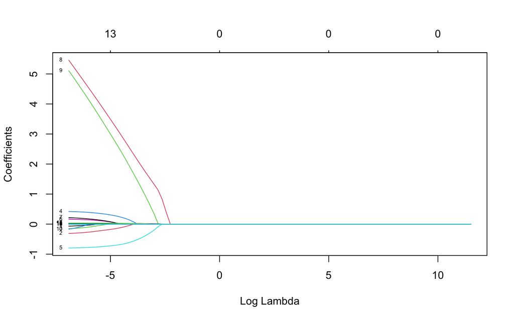

```r
plot(glmmod, xvar= 'lambda', label=T)
```

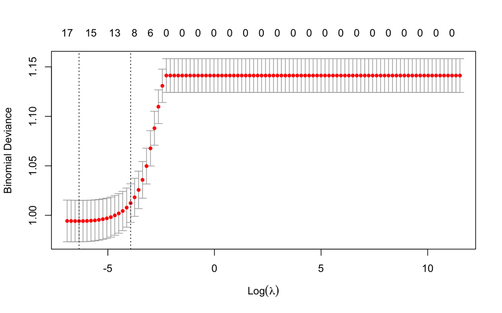

```r
plot(glmmod_cv)
```

```r
coef(glmmod_cv, c(glmmod_cv$lambda.min))
```

```
20 x 1 sparse Matrix of class "dgCMatrix"
                                               s1
(Intercept)                         -6.3007218549
educHigh School Diploma, GED        -0.0494868437
educSome College, Vocational School -0.2886519512
educCollege (BS, BA) degree or more -0.1264566692
DIABETESDiabetes History             0.4053474020
SEXWomen                            -0.7857799141
CURSMOKECurrently Smoker             0.1526685750
BPMEDSCurrently Using BP Meds        0.1942459914
PREVAPAngina History                 4.8944785339
PREVMIMI History                     4.5222871287
PREVSTRKStroke History              -0.0855118927
PREVHYPHTN History                   .
TOTCHOL                              0.0059664416
AGE                                  0.0274951590
SYSBP                                0.0150408509
DIABP                                .
CIGPDAY                              0.0001403027
BMI                                  0.0359991993
HEARTRTE                            -0.0067538015
GLUCOSE                              0.0041698193
```

```r
lasso.model <- glm(ANYCHD ~ educ + DIABETES + SEX + CURSMOKE + BPMEDS + PREVAP + PREVMI + PREVSTRK +AGE + SYSBP +BMI, family="binomial", data=lassoData)
options(max.print=1000000)
summary (lasso.model)
```

```
Call:
glm(formula = ANYCHD ~ educ + DIABETES + SEX + CURSMOKE + BPMEDS +
    PREVAP + PREVMI + PREVSTRK + AGE + SYSBP + BMI, family = "binomial",
    data = lassoData)

Deviance Residuals:
     Min        1Q    Median        3Q       Max
-1.63822  -0.76272  -0.55964   0.00035   2.44357

Coefficients:
                                      Estimate Std. Error z value Pr(>|z|)
(Intercept)                          -5.693924   0.501318 -11.358  < 2e-16 ***
educHigh School Diploma, GED         -0.075412   0.115929  -0.651  0.51537
educSome College, Vocational School  -0.308591   0.146681  -2.104  0.03539 *
educCollege (BS, BA) degree or more  -0.159410   0.155144  -1.027  0.30419
DIABETESDiabetes History              0.698050   0.296047   2.358  0.01838 *
SEXWomen                             -0.774006   0.099031  -7.816 5.46e-15 ***
CURSMOKECurrently Smoker              0.184108   0.100388   1.834  0.06666 .
BPMEDSCurrently Using BP Meds         0.258213   0.274823   0.940  0.34744
PREVAPAngina History                 16.864209 302.595245   0.056  0.95556
PREVMIMI History                     16.595684 360.232296   0.046  0.96325
PREVSTRKStroke History               -0.243456   0.868047  -0.280  0.77912
AGE                                   0.035087   0.006257   5.607 2.06e-08 ***
SYSBP                                 0.016191   0.002589   6.253 4.04e-10 ***
BMI                                   0.040201   0.012545   3.205  0.00135 **
---
Signif. codes:  0 '***' 0.001 '**' 0.01 '*' 0.05 '.' 0.1 ' ' 1

(Dispersion parameter for binomial family taken to be 1)

    Null deviance: 3151.2  on 2762  degrees of freedom
Residual deviance: 2742.8  on 2749  degrees of freedom
AIC: 2770.8

Number of Fisher Scoring iterations: 15
```

```r
lasso.model.coe <- glmnet(x=xfactors, y=yfactor,
                      alpha  = 1,
                      lambda =glmmod_cv$lambda.min, family="binomial")


lasso.model$beta
```

```r
# Compare them with  OLS - in this case, the coefficients are similar because the penalization was low
```

To visualize the fitting of the all three regression model, we installed the package stargazer to align all the results for comparison

```r
library(stargazer)
stargazer(full.model, stepwise.model, lasso.model, type = "text")
```

```
====================================================================
                                          Dependent variable:
                                    --------------------------------
                                                 ANYCHD
                                       (1)        (2)        (3)
--------------------------------------------------------------------
educHigh School Diploma, GED          -0.091                -0.075
                                     (0.117)               (0.116)

educSome College, Vocational School  -0.338**              -0.309**
                                     (0.148)               (0.147)

educCollege (BS, BA) degree or more   -0.189                -0.159
                                     (0.156)               (0.155)

DIABETESDiabetes History              0.444                0.698**
                                     (0.361)               (0.296)

SEXWomen                            -0.810***  -0.811***  -0.774***
                                     (0.106)    (0.100)    (0.099)

CURSMOKECurrently Smoker              0.179      0.197*     0.184*
                                     (0.158)    (0.102)    (0.100)

BPMEDSCurrently Using BP Meds         0.254                 0.258
                                     (0.280)               (0.275)

PREVAPAngina History                  16.877     16.878     16.864
                                    (302.839)  (303.521)  (302.595)

PREVMIMI History                      16.610     16.570     16.596
                                    (359.324)  (359.560)  (360.232)

PREVSTRKStroke History                -0.281                -0.243
                                     (0.867)               (0.868)

PREVHYPHTN History                    -0.038
                                     (0.141)

TOTCHOL                              0.006***   0.006***
```

[output cut: 17 more lines]

```
HEARTRTE                             -0.008*    -0.008*
                                     (0.004)    (0.004)

GLUCOSE                               0.005*    0.006***
                                     (0.003)    (0.002)

Constant                            -6.461***  -6.882***  -5.694***
                                     (0.703)    (0.574)    (0.501)

--------------------------------------------------------------------
Observations                          2,763      2,763      2,763
Log Likelihood                      -1,354.219 -1,358.321 -1,371.406
Akaike Inf. Crit.                   2,748.437  2,738.642  2,770.812
====================================================================
Note:                                    *p<0.1; **p<0.05; ***p<0.01
```

## Logistic regression

For binary logistic regression, its target variables are binary, which means it has to be 0 or 1. In the dataset, the risk factors which are 0 ro 1 are SEX, BPMED, CURSMOKE, DIABETES, PREVAP, PRECHD, PREVMI, PREVHYP. We use this eight factors to show their correlation with CHD.

```r
library(DAAG)
library(ggplot2)
library(cowplot)


BiANYCHD.full <- glm(formula = ANYCHD ~ SEX + BPMEDS + CURSMOKE + DIABETES + PREVAP + PREVCHD + PREVMI + PREVHYP , family="binomial",data = FRAMINGHAM.CLEAN.ALL3)
summary(BiANYCHD.full)
```

```
Call:
glm(formula = ANYCHD ~ SEX + BPMEDS + CURSMOKE + DIABETES + PREVAP +
    PREVCHD + PREVMI + PREVHYP, family = "binomial", data = FRAMINGHAM.CLEAN.ALL3)

Deviance Residuals:
     Min        1Q    Median        3Q       Max
-1.42329  -0.78718  -0.58142   0.00035   1.94087

Coefficients:
                               Estimate Std. Error z value Pr(>|z|)
(Intercept)                    -0.98633    0.08620 -11.443  < 2e-16 ***
SEXWomen                       -0.70569    0.08800  -8.019 1.07e-15 ***
BPMEDSCurrently Using BP Meds   0.55644    0.25342   2.196 0.028112 *
CURSMOKECurrently Smoker       -0.02651    0.08832  -0.300 0.764023
DIABETESDiabetes History        0.93087    0.28016   3.323 0.000892 ***
PREVAPAngina History           -0.09314  823.11477   0.000 0.999910
PREVCHDCoronary HD History     17.68497  883.81740   0.020 0.984036
PREVMIMI History               -0.10392  701.43684   0.000 0.999882
PREVHYPHTN History              0.61709    0.09531   6.474 9.52e-11 ***
---
Signif. codes:  0 '***' 0.001 '**' 0.01 '*' 0.05 '.' 0.1 ' ' 1

(Dispersion parameter for binomial family taken to be 1)

    Null deviance: 3609.3  on 3165  degrees of freedom
Residual deviance: 3275.8  on 3157  degrees of freedom
  (40 observations deleted due to missingness)
AIC: 3293.8

Number of Fisher Scoring iterations: 15
```

```r
BiANYCHD.reduced <- glm(formula = ANYCHD ~ SEX + BPMEDS + DIABETES + PREVHYP , family = "binomial", data = FRAMINGHAM.CLEAN.ALL3)
summary(BiANYCHD.reduced)
```

```
Call:
glm(formula = ANYCHD ~ SEX + BPMEDS + DIABETES + PREVHYP, family = "binomial",
    data = FRAMINGHAM.CLEAN.ALL3)

Deviance Residuals:
    Min       1Q   Median       3Q      Max
-1.4582  -0.8187  -0.5989   1.1795   1.9010

Coefficients:
                              Estimate Std. Error z value Pr(>|z|)
(Intercept)                   -0.92099    0.06500 -14.168  < 2e-16 ***
SEXWomen                      -0.70652    0.08380  -8.431  < 2e-16 ***
BPMEDSCurrently Using BP Meds  0.66571    0.24018   2.772 0.005577 **
DIABETESDiabetes History       0.91605    0.27471   3.335 0.000854 ***
PREVHYPHTN History             0.64453    0.09193   7.011 2.37e-12 ***
---
Signif. codes:  0 '***' 0.001 '**' 0.01 '*' 0.05 '.' 0.1 ' ' 1

(Dispersion parameter for binomial family taken to be 1)

    Null deviance: 3609.3  on 3165  degrees of freedom
Residual deviance: 3456.7  on 3161  degrees of freedom
  (40 observations deleted due to missingness)
AIC: 3466.7

Number of Fisher Scoring iterations: 4
```

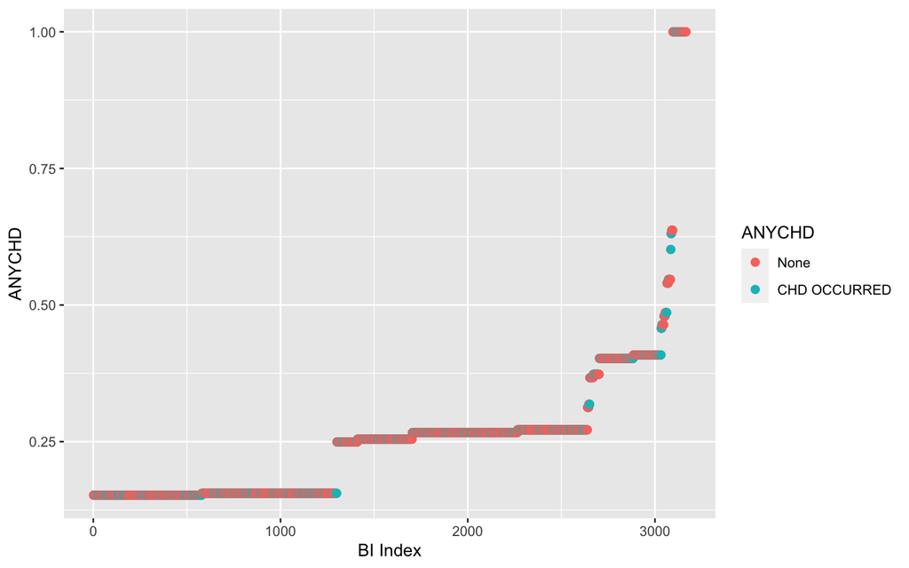

```r
predicted.data0 <- data.frame(probability.of.ANYCHD0=BiANYCHD.full$fitted.values,ANYCHD=FRAMINGHAM.CLEAN.ALL3$ANYCHD[0:3166])
predicted.data0 <- predicted.data0[order(predicted.data0$probability.of.ANYCHD0, decreasing = FALSE),]
predicted.data0$rank <- 1:nrow(predicted.data0)
ggplot(data = predicted.data0,aes(x = rank,y =probability.of.ANYCHD0 ))+geom_point(aes(color=ANYCHD),alpha=1,shape=1,stroke=2,size = 0.1)+xlab("BI Index")+ylab("ANYCHD")
```

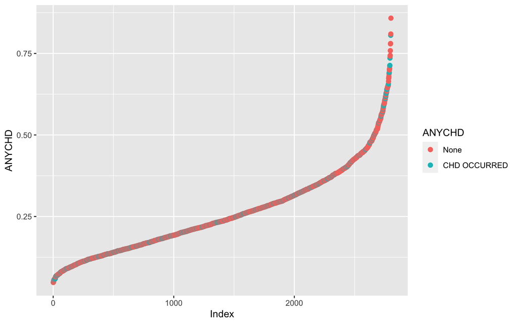

```r
LRANYCHD.full<-glm(formula = ANYCHD~TOTCHOL+AGE+SYSBP+DIABP+CIGPDAY+BMI+HEARTRTE+GLUCOSE+educ+PREVSTRK,family="binomial",data = FRAMINGHAM.CLEAN.ALL3)
LRANYCHD.reduced <- glm(formula = ANYCHD~TOTCHOL+AGE+SYSBP+CIGPDAY+BMI+HEARTRTE+GLUCOSE,family="binomial",data = FRAMINGHAM.CLEAN.ALL3)
#anova(LRANYCHD.reduced,LRANYCHD.full,test="Chisq")

predicted.data <- data.frame(probability.of.ANYCHD=LRANYCHD.full$fitted.values,ANYCHD=FRAMINGHAM.CLEAN.ALL3$ANYCHD[0:2801])
predicted.data <- predicted.data[order(predicted.data$probability.of.ANYCHD, decreasing = FALSE),]
predicted.data$rank <- 1:nrow(predicted.data)
ggplot(data = predicted.data,aes(x = rank,y =probability.of.ANYCHD ))+geom_point(aes(color=ANYCHD),alpha=1,shape=1,stroke=2,size = 0.1)+xlab("Index")+ylab("ANYCHD")
```

```r
summary(LRANYCHD.full)
```

```
Call:
glm(formula = ANYCHD ~ TOTCHOL + AGE + SYSBP + DIABP + CIGPDAY +
    BMI + HEARTRTE + GLUCOSE + educ + PREVSTRK, family = "binomial",
    data = FRAMINGHAM.CLEAN.ALL3)

Deviance Residuals:
    Min       1Q   Median       3Q      Max
-1.7387  -0.7917  -0.6046   0.9615   2.3985

Coefficients:
                                     Estimate Std. Error z value Pr(>|z|)
(Intercept)                         -6.835858   0.572333 -11.944  < 2e-16 ***
TOTCHOL                              0.005004   0.001081   4.629 3.67e-06 ***
AGE                                  0.033697   0.006273   5.372 7.79e-08 ***
SYSBP                                0.011140   0.003750   2.971  0.00297 **
DIABP                                0.006303   0.006584   0.957  0.33840
CIGPDAY                              0.016650   0.003883   4.287 1.81e-05 ***
BMI                                  0.046263   0.012202   3.791  0.00015 ***
HEARTRTE                            -0.011431   0.004049  -2.823  0.00476 **
GLUCOSE                              0.006408   0.002129   3.010  0.00262 **
educHigh School Diploma, GED        -0.116274   0.111963  -1.039  0.29904
educSome College, Vocational School -0.341581   0.138914  -2.459  0.01393 *
educCollege (BS, BA) degree or more -0.045205   0.146478  -0.309  0.75761
PREVSTRKStroke History              -0.253675   0.850991  -0.298  0.76563
---
Signif. codes:  0 '***' 0.001 '**' 0.01 '*' 0.05 '.' 0.1 ' ' 1

(Dispersion parameter for binomial family taken to be 1)

    Null deviance: 3203.4  on 2800  degrees of freedom
Residual deviance: 2968.2  on 2788  degrees of freedom
  (405 observations deleted due to missingness)
AIC: 2994.2

Number of Fisher Scoring iterations: 4
```

```r
summary(LRANYCHD.reduced)
```

```
Call:
glm(formula = ANYCHD ~ TOTCHOL + AGE + SYSBP + CIGPDAY + BMI +
    HEARTRTE + GLUCOSE, family = "binomial", data = FRAMINGHAM.CLEAN.ALL3)

Deviance Residuals:
    Min       1Q   Median       3Q      Max
-1.7908  -0.7834  -0.6096   0.9577   2.3162

Coefficients:
             Estimate Std. Error z value Pr(>|z|)
(Intercept) -6.887610   0.526597 -13.079  < 2e-16 ***
TOTCHOL      0.004703   0.001046   4.494 6.98e-06 ***
AGE          0.035088   0.005953   5.895 3.75e-09 ***
SYSBP        0.013158   0.002427   5.422 5.89e-08 ***
CIGPDAY      0.017247   0.003813   4.523 6.10e-06 ***
BMI          0.054562   0.011628   4.692 2.70e-06 ***
HEARTRTE    -0.011804   0.003998  -2.952  0.00315 **
GLUCOSE      0.006646   0.002119   3.137  0.00171 **
---
Signif. codes:  0 '***' 0.001 '**' 0.01 '*' 0.05 '.' 0.1 ' ' 1

(Dispersion parameter for binomial family taken to be 1)

    Null deviance: 3282.3  on 2872  degrees of freedom
Residual deviance: 3050.5  on 2865  degrees of freedom
  (333 observations deleted due to missingness)
AIC: 3066.5

Number of Fisher Scoring iterations: 4
```

## Logistic Regression Results

In binary logistic regression model,we analyzed the correlation between risk factors and CHD. It shows SEXWomen, DIABETESDiabetes History,PREVHYPHTN History have strong correlation with CHD, and BPMEDS has less correlation with CHD. Also, Sexwomen has the smallest P-value. We are going to retest those high risk factors to see if they are dummy variables and to show their correlation.Based on the table, it shows there is no dummy variables and except BPMEDS has less correlation, other three show strong correlation with CHD, Also, except the binary varibles, we also test the binomial logistic regression with all other factors which are not 0 or 1. The factors includes TOTCHOL,AGE, SYSBP,DIABP, CIGPDAY, BMI, HEARTRTE, GLUCOSE, educ, PREVSTRK. The TOTCHOL,AGE,CIGPDAY,BMI show stronger relation with CHD, and SYSBP,HEARTRTE,GLUCOSE show less relation. When we do restest and to see if dummy varibles exist, it shgws all factors do have influence on CHD. Age is the risk factor which has the smallest p-value, showing the strongest correlation with CHD.